# MA5761 Homework #7

Karthik Garimella

For homework assignments in this course, you will be provided with a knitted R notebook and the .rmd file used to create it. You are *encouraged* (but not required) to use the .rmd file as a template for your solutions.

## Hours-to-failure of Air Conditioning Equipment

The data frame `aircondit7` in the `boot` package consists of times between failure of air conditioning equipment in a Boeing 720 aircraft. An estimator of what is called the *hazard rate* $\lambda$ would be
$$\hat\lambda=\frac1{\bar X}$$
where $\bar X$ is the sample mean of the times between failures of the equipment.

For problems in this first exercise, you should write R code that *does not* use any installed R packages (such as functions from the `boot` or `bootstrap` packages).

### Jackknife Estimates

Use the jackknife to estimate the bias and standard error of the estimator $\hat\lambda$. Also provide a bias-corrected point estimate of $\lambda$. Does the bias in this estimator appear to be “large”? Calculate the ratio of the estimated bias over the estimated standard error.

Your code should not use any functions from other packages (such as `boot` or `bootstrap`), but should rely solely on functions from the base R installation.

You will need the jackknife replicates in the next part of this exercise, so you should store those in a vector for easy use.

```r
library(boot)

aircond <- aircondit7$hours

(aircond)
```

```
##  [1]   3   5   5  13  14  15  22  22  23  30  36  39  44  46  50  72  79  88  97
## [20] 102 139 188 197 210
```

```r
print(n <- length(aircond))
```

```
## [1] 24
```

```r
print(theta_hat <- 1/mean(aircond))
```

```
## [1] 0.01559454
```

```r
print(air_samp <- sapply(1:n, function(row) (1/mean(aircond[-row ]))))
```

```
##  [1] 0.01497396 0.01499348 0.01499348 0.01507208 0.01508197 0.01509186
##  [7] 0.01516150 0.01516150 0.01517150 0.01524188 0.01530273 0.01533333
## [13] 0.01538462 0.01540522 0.01544661 0.01567825 0.01575342 0.01585114
## [19] 0.01595007 0.01600557 0.01642857 0.01702443 0.01713860 0.01730625
```

```r
print(mean_hazard_rate <- mean(air_samp))
```

```
## [1] 0.015623
```

###### Jackknife Bias

```r
print(jack_bias <- (n-1) * (mean_hazard_rate - theta_hat))
```

```
## [1] 0.0006545667
```

###### Jackknife Standard Error

```r
print(jack_se <- sqrt((n-1) * mean((air_samp - mean_hazard_rate)^2)))
```

```
## [1] 0.003284622
```

###### Jackknife bias-corrected point estimate

```r
print(jack_est <- theta_hat - jack_bias)
```

```
## [1] 0.01493998
```

###### Jackknife ratio of the estimated bias over the estimated standard error.

```r
print(bias_se_ratio <- jack_bias/jack_se)
```

```
## [1] 0.1992822
```

### Bootstrap Estimates

Create a sample $B=2000$ bootstrap replicates $\hat\lambda^\ast$. *Do not* use the `boot` (or related functions) for this exercise.

Create a histogram of the estimated sampling distribution of $\hat\lambda$ and make comments on it. Particularly, does it appear plausible that this sampling distribution is normally distributed?

Use the bootstrap samples to estimate the bias and standard error of $\hat\lambda$. Also produce a bias-corrected point estimate of $\lambda$, and also calculate the ratio of bias over standard error.

###### Sample Size

```r
B <- 2000
```

###### Bootstrap Sampling

```r
boot_samples <- replicate(B, aircond[sample.int(n, n, replace = TRUE)])
```

###### Dimensions of the samples

```r
dim(boot_samples)
```

```
## [1]   24 2000
```

```r
boot_mean <- apply(boot_samples, 2, function(row) (1/mean(aircond[-row ])))
```

###### Mean of Bootstrap Sample

```r
print(bootstrap_estimate <- mean(boot_mean))
```

```
## [1] 0.01675258
```

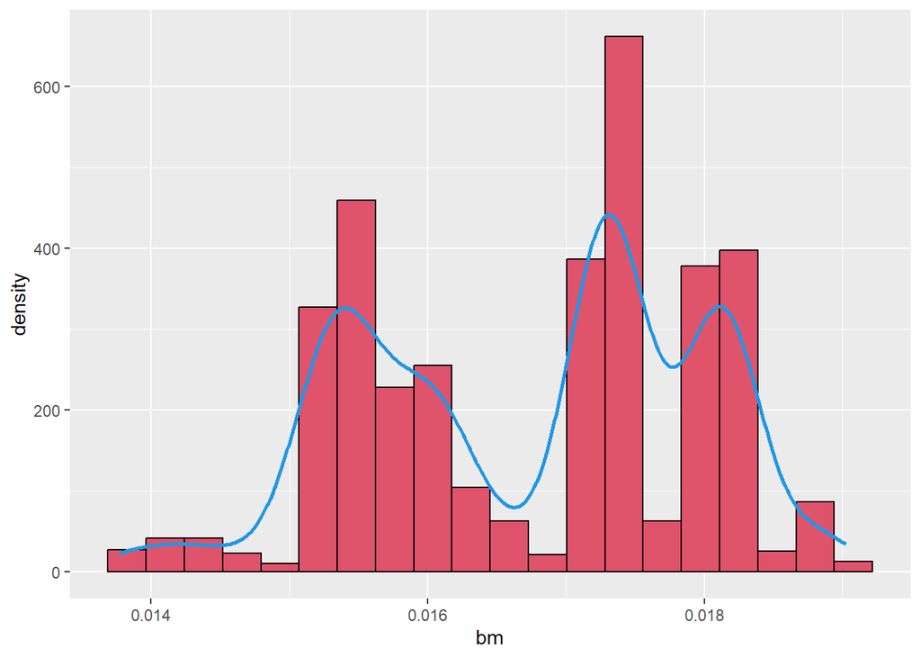

```r
# histogram of the estimated sampling distribution of λ^

library(ggplot2)
data.frame(bm <- boot_mean) |> ggplot(aes(x = bm)) +
  geom_histogram(aes(y = after_stat(density)), bins = 20, fill = 2, col = 1)+
  geom_density(lwd = 1, col = 4)
```

###### Bootstrap Bias

```r
print(bias_be <- mean(boot_mean) - theta_hat)
```

```
## [1] 0.001158041
```

###### Bootstrap Standard Error

```r
# bootstrap standard error
print(se_be <- mean((boot_mean - theta_hat)^2))
```

```
## [1] 2.775493e-06
```

###### Bootstrap bias-corrected point estimate

```r
# bootstrap bias-corrected point estimate
print(bce_be <- theta_hat - bias_be)
```

```
## [1] 0.0144365
```

###### Bootstrap ratio of bias over standard error

```r
# bootstrap ratio of bias over standard error
print(bias_se_be <- bias_be/se_be)
```

```
## [1] 417.2378
```

### Best Estimator

Under the assumption that this population comes from an exponential distribution, it can be proven that the *minimum-variance unbiased estimator* is equal to
$$\hat\lambda_{MVUE}=\frac{n-1}{\sum_{j=1}^nX_j}=\frac{n-1}{n}\cdot\frac1{\bar
X}$$
The standard error of this estimator is equal to
$$\mathsf{SE}(\hat\lambda_{MVUE})=\frac{\lambda}{\sqrt{n-2}}$$
which depends on the unknown parameter $\lambda$. The typical way of estimating this standard error would be as
$$\widehat{\mathsf{SE}}(\hat\lambda_{MVUE})=\frac{\hat\lambda_{MVUE}}{\sqrt{n-2}}$$

```r
print(lambda_hat_mvue <- ((n-1)/n) * (1/mean(aircond)))
```

```
## [1] 0.01494477
```

###### Standard Error

```r
print(mvue_se <- lambda_hat_mvue/sqrt(n-2))
```

```
## [1] 0.003186236
```

###### Point Estimate to the bias-corrected point estimates comparison

```r
point_est_comp <- c(jack_est, bce_be, lambda_hat_mvue)
names(point_est_comp) <- c('jackknife','bootstrap', 'point estimate')

print(point_est_comp)
```

```
##      jackknife      bootstrap point estimate
##     0.01493998     0.01443650     0.01494477
```

###### Estimated Standard Errors of these three estimators

```r
se_est_comp <- c(jack_se, se_be, mvue_se)
names(se_est_comp) <- c('jackknife','bootstrap', 'point estimate')

print(se_est_comp)
```

```
##      jackknife      bootstrap point estimate
##   3.284622e-03   2.775493e-06   3.186236e-03
```

### Bootstrap Confidence Intervals

Use your bootstrap samples to create confidence intervals using the four methods studied in class:

- the standard normal confidence interval
- the basic confidence interval
- the percentile confidence interval
- the BCa confidence interval

You should use your own code to produce these confidence intervals (i.e. *do not* use the `boot.ci()` function).

It can also be shown that, under the assumption that the sample comes from an exponential distribution, that an *exact* 95% confidence interval takes the form
$$\left(\frac{\chi^2_{2n,0.025}}{2\sum_{j=1}^nX_j},\frac{\chi^2_{2n,0.975}}{2\sum_{j=1}^nX_j}\right)$$
where $\chi^2_{2n,0.025}$ and $\chi^2_{2n,0.975}$ are the 0.025 and 0.975-quantiles from the $\chi^2$ distribution with $2n$ degrees of freedom. Calculate this confidence interval as well.

Place all five of these confidence intervals in a data frame (or some other rectangular array object) with a column (or row names) indicating the type of interval and further columns `LCL`, `UCL`, and `Width` (the lower confidence limit, upper confidence limit, and width of the interval). Print this data frame (or matrix) and compare the resulting intervals. Which of these intervals is the narrowest? Which do you think is least trustworthy?

###### Standard Normal Confidence Interval

```r
z <- qnorm(0.975) # for 95% CI

stand_ci <- mean(boot_mean) + c(-1, 1) * z * sd(boot_mean)
names(stand_ci) <- c('Lower CI', 'Upper CI')

print(stand_ci)
```

```
##   Lower CI   Upper CI
## 0.01440459 0.01910058
```

###### Basic Bootstrap Confidence Interval

```r
print(basic_boot_ci <- 2 * mean(boot_mean) - quantile(boot_mean, c(0.975, 0.025)))
```

```
##      97.5%       2.5%
## 0.01476749 0.01915796
```

###### Percentile Confidence Interval

```r
print(perc_ci <- quantile(boot_mean, c(0.025, 0.975)))
```

```
##       2.5%      97.5%
## 0.01434720 0.01873767
```

###### BCa Confidence Interval

```r
# BCa confidence interval

theta_hat_bc <- (1/mean(aircond))

p <- mean(boot_mean < theta_hat_bc)

z0_hat <- qnorm(p)

air_samp <- sapply(1:n, function(row) (1/mean(aircond[-row ])))
a_hat <- sum((mean(air_samp)-air_samp)^3) / (6*sum((air_samp-mean(air_samp))^2)^(3/2))

z <- qnorm(c(0.025, 0.975))
alpha <- pnorm(z0_hat + (z0_hat+z)/(1-a_hat*(z0_hat+z)))


print(bca_ci_rat3 <- quantile(boot_mean, alpha))
```

```
## 0.009863541%    68.61594%
##   0.01376812   0.01744720
```

###### χ2 distribution CI

```r
# χ2 distribution CI

chisq_lcl <- qchisq(0.025, df = 2 * n)/ (2 * sum(aircond))
chisq_ucl <- qchisq(0.975, df = 2 * n)/ (2 * sum(aircond))
```

###### Dataframe for CI Comparison

```r
# DF comparison of CIs
LCL <- c(stand_ci[1], basic_boot_ci[1], perc_ci[1], bca_ci_rat3[1], chisq_lcl)

UCL <- c(stand_ci[2], basic_boot_ci[2], perc_ci[2], bca_ci_rat3[2], chisq_ucl)

Width <- c(stand_ci[2] - stand_ci[1], basic_boot_ci[2] - basic_boot_ci[1],
           perc_ci[2] - perc_ci[1], bca_ci_rat3[2] - bca_ci_rat3[1],
           chisq_ucl - chisq_lcl)

df1 <- data.frame(LCL, UCL, Width, row.names = c('standard normal', 'basic confidence', 'percentile',
                                                 'BCa', 'Chisq'))

df1
```

|  | LCL | UCL | Width |
| --- | --- | --- | --- |
| standard normal | 0.014404588 | 0.01910058 | 0.004695990 |
| basic confidence | 0.014767493 | 0.01915796 | 0.004390470 |
| percentile | 0.014347202 | 0.01873767 | 0.004390470 |
| BCa | 0.013768116 | 0.01744720 | 0.003679083 |
| Chisq | 0.009991717 | 0.02242449 | 0.012432775 |

The BCa Confidence Interval seems to have the narrowest interval. And the least trustworthy CI seems to be the Chisq among all 5 shown above. Excluding the chisq, the standard normal looks the 2nd most least trustworthy of all CIs.

## Exam Scores

The data frame `scor` in the `bootstrap` package contains test scores on stuents who took examinations in five subjects (mechanics, vectors, algebra, analysis, and statistics).

In a principal component analysis, we study the eigenvalues $\lambda_j$ and eigenvectors $e_j$ of the covariance matrix $\Sigma$. One important statistic is
$$\theta=\frac{\lambda_1}{\sum_{j=1}^5\lambda_j}$$
which is loosely interpreted as the proportion of variance by the first principal component.

A natural choice of estimator of $\theta$ is
$$\hat\theta=\frac{\hat\lambda_1}{\sum_{j=1}^5\hat\lambda_j}$$
where $\hat\lambda_j$ are the eigenvalues of the *sample covariance* matrix $\hat\Sigma$ of the five variables.

### Proportion of Explained Variance

Write a function which inputs a single data frame and returns the estimate $\hat\theta$ defined above. Note that the `eigen()` function is a useful R function that can obtain eigenvalues and eigenvectors of a square matrix.

Apply `eigen()` to the covariance matrix of the `scor` data frame and study the output. Notice that the eigenvalues are sorted from largest to smallest, so that $\hat\lambda_1$ will be the first eigenvalue.

Report the value of $\hat\theta$ for the `scor` data.

###### Proportion of Explained Variance Function

```r
library(bootstrap)

prop <- function(df){
  cov_df <- cov(df)
  eig <- eigen(cov_df)$values
  return(eig[1]/sum(eig))

}

print(pev <- prop(scor))
```

```
## [1] 0.619115
```

### Jackknife Estimates

Use your function to obtain an estimate of bias and standard error of $\hat\theta$, and also produce a bias-corrected estimate of $\hat\theta$. You may code the jackknife sampling on your own, or alternatively may use functions from other packages that implement jackknife sampling.

###### Getting value of ‘n’

```r
print(n <- nrow(scor))
```

```
## [1] 88
```

```r
jack_values <- nrow(scor)
```

###### Jackknife Estimate

```r
for (i in 1:n) {
  cov_df <- cov(scor[-i, ])

  eig_df <- eigen(cov_df)$values

  jack_values[i] <- eig_df[1]/sum(eig_df)

}

print(jack_values)
```

```
##  [1] 0.6023604 0.6036648 0.6035954 0.6116595 0.6117515 0.6131099 0.6135186
##  [8] 0.6140626 0.6136765 0.6175460 0.6161043 0.6180692 0.6178629 0.6207790
## [15] 0.6221186 0.6197730 0.6188527 0.6195213 0.6201325 0.6215819 0.6190128
## [22] 0.6208870 0.6289743 0.6191910 0.6192610 0.6199021 0.6203142 0.6314490
## [29] 0.6207575 0.6223535 0.6217189 0.6202163 0.6255607 0.6238954 0.6198098
## [36] 0.6222577 0.6205061 0.6203566 0.6203710 0.6224668 0.6216371 0.6199615
## [43] 0.6206110 0.6197188 0.6207670 0.6204011 0.6200534 0.6219368 0.6207667
## [50] 0.6206604 0.6204982 0.6228878 0.6218697 0.6284118 0.6212213 0.6259294
## [57] 0.6216479 0.6203075 0.6214231 0.6198478 0.6277876 0.6209359 0.6191791
## [64] 0.6214425 0.6193932 0.6275658 0.6192405 0.6197967 0.6190270 0.6203868
## [71] 0.6209426 0.6206899 0.6223269 0.6182703 0.6186218 0.6237463 0.6196369
## [78] 0.6191776 0.6175143 0.6168017 0.6270800 0.6153531 0.6125564 0.6119130
## [85] 0.6131326 0.6119919 0.6053375 0.6037964
```

###### Jackknife Bias

```r
print(eg_jack_bias <- (n-1) * (mean(jack_values) - pev))
```

```
## [1] 0.001069139
```

###### Jackknife Standard Error

```r
print(eg_jack_se <- sqrt((n-1) * mean((jack_values-mean(jack_values))^2)))
```

```
## [1] 0.04955231
```

###### Jackknife Bias Corrected Estimate

```r
print(eg_jack_est <- pev - eg_jack_bias)
```

```
## [1] 0.6180459
```

### Bootstrap Estimates

Sample $B=2000$ bootstrap replicates $\hat\theta^\ast$ from the `scor` data set. You may either use the `boot()` function, or code this on your own.

###### Assigning value of B for number of replicates

```r
B <- 2000
print(n <- nrow(scor))
```

```
## [1] 88
```

```r
boot_value <- nrow(scor)
boot_value
```

```
## [1] 88
```

###### Bootstrap Sampling

```r
for (b in 1:B){
  for (i in 1:n) {

  boot_mat <- matrix(nrow = n, ncol = 5, byrow = TRUE)

  boot_mat <- scor[sample(1:n, n, replace = TRUE), ]
  # sample_n(scor, i)
  cov_boot <- cov(boot_mat)
  boot_eigen <- eigen(cov_boot)$values
  boot_value[i] <- boot_eigen[1]/sum(boot_eigen)
}
}
```

###### Saved boot_value

```r
save(boot_value, file = "my_saved_boot_value.Rdata")
```

###### Loading boot_value

```r
load("my_saved_boot_value.Rdata")
boot_value
```

```
##  [1] 0.6249056 0.5605809 0.6319358 0.5872819 0.6387311 0.6202904 0.6661323
##  [8] 0.5996144 0.6089715 0.6240149 0.5267332 0.6727781 0.6244216 0.6713247
## [15] 0.6332486 0.5334120 0.5365122 0.6687563 0.5909975 0.5740275 0.6391036
## [22] 0.5791114 0.6119024 0.5172520 0.6461442 0.6427248 0.7206294 0.6439523
## [29] 0.7174585 0.6095826 0.5454575 0.6871087 0.6091407 0.6792447 0.5958198
## [36] 0.6178467 0.5912850 0.5428385 0.6270790 0.6344342 0.6115386 0.5963298
## [43] 0.6384369 0.5930302 0.6247617 0.6311657 0.6611725 0.6465072 0.6405941
## [50] 0.6393776 0.6438555 0.5871567 0.6086174 0.6659892 0.7112476 0.6666482
## [57] 0.6819940 0.6179616 0.5434324 0.6449193 0.6439453 0.5898466 0.5178213
## [64] 0.5443245 0.5997367 0.5873028 0.6557195 0.6765973 0.6519267 0.5606675
## [71] 0.6079740 0.6273487 0.6977168 0.7006879 0.5898780 0.6980077 0.5948093
## [78] 0.5309940 0.6743008 0.5367922 0.5983255 0.6617272 0.6387861 0.6896515
## [85] 0.6759783 0.5504291 0.6510792 0.6350026
```

###### Histogram of the Estimated Sampling Distribution

Create a histogram of the estimated sampling distribution of $\hat\theta$ and make some brief comments on it. Is it plausible that this is normally distributed?

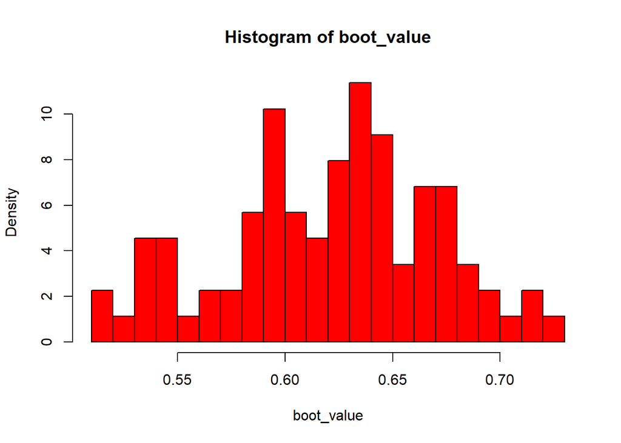

```r
hist(boot_value, prob = TRUE, breaks  = 20, col = 'red')
```

The above histogram does not look normally distributed as much because the distribution is not as even as in a normal distribution with high left tail.

Obtain estimates of the bias and standard error of $\hat\theta$, as well as a bias-corrected estimate of $\theta$, from your bootstrap replicates. Further, calculate 95% confidence intervals on $\theta$ using the four types of bootstrap confidence intervals investigated in class. Do you see any major differences between these different intervals?

###### Bootstrap Bias

```r
# Bias

print(bias_be <- mean(boot_value) - pev)
```

```
## [1] 0.002417916
```

###### Bootstrap Standard Error

```r
# bootstrap standard error
print(se_be <- mean((boot_value - pev)^2))
```

```
## [1] 0.002390559
```

###### Bootstrap Bias Corrected Point Estimate

```r
print(bce_be <- pev - bias_be)
```

```
## [1] 0.6166971
```

###### Standard Normal Confidence Interval

```r
z <- qnorm(0.975)

stand_ci <- mean(boot_value) + c(-1, 1) * z * sd(boot_value)
names(stand_ci) <- c('Lower CI', 'Upper CI')

print(stand_ci)
```

```
##  Lower CI  Upper CI
## 0.5252725 0.7177934
```

###### Basic Bootstrap Confidence Interval

```r
# basic bootstrap confidence interval

print(basic_boot_ci <- 2 * mean(boot_value) - quantile(boot_value, c(0.975, 0.025)))
```

```
##     97.5%      2.5%
## 0.5336663 0.7155871
```

###### Percentile Confidence Interval

```r
# percentile confidence interval

print(perc_ci <- quantile(boot_value, c(0.025, 0.975)))
```

```
##      2.5%     97.5%
## 0.5274788 0.7093996
```

###### BCa Confidence Interval

```r
# BCa confidence interval

theta_hat_bc <- pev

p <- mean(boot_value < theta_hat_bc)

z0_hat <- qnorm(p)

a_hat <- sum((mean(boot_value)-boot_value)^3) / (6*sum((boot_value-mean(boot_value))^2)^(3/2))

z <- qnorm(c(0.025, 0.975))
alpha <- pnorm(z0_hat + (z0_hat+z)/(1-a_hat*(z0_hat+z)))


print(bca_ci_rat3 <- quantile(boot_value, alpha))
```

```
## 1.299112% 95.43722%
## 0.5189819 0.6980891
```

###### Dataframe for CI comparison

```r
LCL <- c(stand_ci[1], basic_boot_ci[1], perc_ci[1], bca_ci_rat3[1])

UCL <- c(stand_ci[2], basic_boot_ci[2], perc_ci[2], bca_ci_rat3[2])

Width <- c(stand_ci[2] - stand_ci[1], basic_boot_ci[2] - basic_boot_ci[1],
                 perc_ci[2] - perc_ci[1], bca_ci_rat3[2] - bca_ci_rat3[1])

boot_df <- data.frame(LCL, UCL, Width, row.names = c('standard normal', 'basic confidence', 'percentile',
                                                 'BCa'))

boot_df
```

|  | LCL | UCL | Width |
| --- | --- | --- | --- |
| standard normal | 0.5252725 | 0.7177934 | 0.1925209 |
| basic confidence | 0.5336663 | 0.7155871 | 0.1819208 |
| percentile | 0.5274788 | 0.7093996 | 0.1819208 |
| BCa | 0.5189819 | 0.6980891 | 0.1791072 |

There does not seem to be a major difference in the Confidence Intervals but the standard normal does show a wider width with the BCa showing the narrowest. Although there might not be a ‘major’ difference in the widths, it does show the standard normal CI is the least trustworthy among all the other CIs.

## Nitrogen Levels in New York Rivers

The data set stored in the file `nyrivers.csv` contains measurements of nitrogen levels in various rivers in New York. The variables in this data set are

- `River`, the name of the river
- `Agr`, the percentage of agricultural land surrounding the river
- `Forest`, the percentage of forested land surrounding the river
- `Rsdntial`, the percentage of residential land surrounding the river
- `ComIndl`, the percentage of land dedicated to commerical and industrial uses surrounding the river
- `Nitrogen`, the nitrogen levels measured in the river

Import this data set into R with the `read.csv` function:

```r
ny <- read.csv('nyrivers.csv', row.names = 1)
```

Note that this file must be in your working directory in order to read the data file.

### Regression: Resampling Cases

Suppose that we wish to fit a linear regression model which estimates `Nitrogen` (the response variable) as a linear combination of `Forest`, `Agr`, and `ComIndl`.

Estimate the bias and standard error of each of the three partial regression coefficients by using *cases resampling* with the bootstrap procedure. Further, create percentile and BCa confidence intervals on each of these coefficients. Compare the estimated bootstrap standard errors with those from the `lm()` function, and also compare your bootstrap confidence intervals to those produced by the `confint()` function.

##### Assigning ny from the csv

```r
ny <- read.csv('C:\\Users\\Karthik Garimella\\Desktop\\Classes\\MA5761 Computational Statistics\\Homework 7\\nyrivers.csv', row.names = 1)

ny
```

|  | Agr | Forest | Rsdntial | ComIndl | Nitrogen |
| --- | --- | --- | --- | --- | --- |
| Olean | 26 | 63 | 1.2 | 0.29 | 1.10 |
| Cassadaga | 29 | 57 | 0.7 | 0.09 | 1.01 |
| Oatka | 54 | 26 | 1.8 | 0.58 | 1.90 |
| Neversink | 2 | 84 | 1.9 | 1.98 | 1.00 |
| Hackensack | 3 | 27 | 29.4 | 3.11 | 1.99 |
| Wappinger | 19 | 61 | 3.4 | 0.56 | 1.42 |
| Fishkill | 16 | 60 | 5.6 | 1.11 | 2.04 |
| Honeoye | 40 | 43 | 1.3 | 0.24 | 1.65 |
| Susquehanna | 28 | 62 | 1.1 | 0.15 | 1.01 |
| Chenango | 26 | 60 | 0.9 | 0.23 | 1.21 |

[output cut: 10 more lines]

###### Plotting Nitrogen, ComIndl, Agr and Forest on the same plot

```r
library(viridis)
```

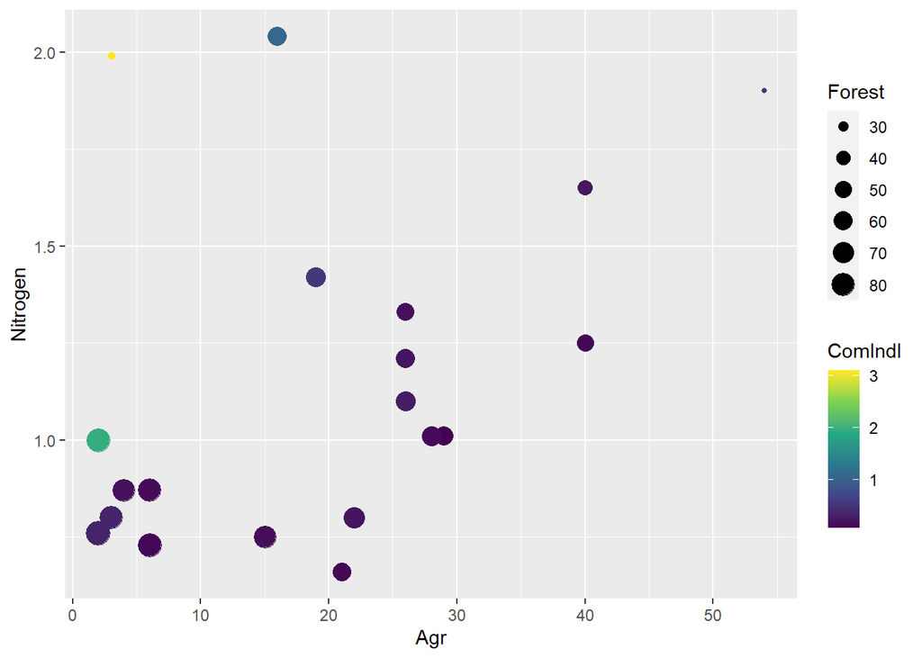

```r
library(ggplot2)
library(boot)

ggplot(ny, aes(x = Agr, y = Nitrogen, color = ComIndl)) +
  geom_point(aes(size = Forest))+
  scale_color_viridis_c()
```

###### Assigning B

```r
B <- 10^3

n <- nrow(ny)
```

###### Bootstrap Sampling

```r
ny_boot <- replicate(B,
                     expr = {
                       rows <- sample.int(n, n, replace = TRUE);
                       new_data <- ny[rows, ];
                       boot_lm <- lm(Nitrogen ~ Forest + Agr + ComIndl, data = new_data);
                       c(coef(boot_lm), sigma(boot_lm))
                     })
dim(ny_boot)
```

```
## [1]    5 1000
```

###### Transposing the ny_boot to get the rows as columns

```r
ny_boot <- t(ny_boot)
```

###### Fitting Linear Model with the ny data

```r
print(ny_lm <- lm(Nitrogen ~ Forest + Agr + ComIndl, ny))
```

```
##
## Call:
## lm(formula = Nitrogen ~ Forest + Agr + ComIndl, data = ny)
##
## Coefficients:
## (Intercept)       Forest          Agr      ComIndl
##    1.507292    -0.010487     0.008307     0.287392
```

```r
print(theta_hat <- c(coef(ny_lm), sigma = sigma(ny_lm)))
```

```
##  (Intercept)       Forest          Agr      ComIndl        sigma
##  1.507291611 -0.010486934  0.008307294  0.287392253  0.256896313
```

###### Comparing Bias

```r
#Bias
print(bias <- (colMeans(ny_boot)) - theta_hat)
```

```
##   (Intercept)        Forest           Agr       ComIndl
##  0.0528332666 -0.0009338728 -0.0015409966  0.1463704132 -0.0506685700
```

```r
coef(ny_lm)
```

```
##  (Intercept)       Forest          Agr      ComIndl
##  1.507291611 -0.010486934  0.008307294  0.287392253
```

###### Comparing Standard Error

```r
#SE
print(se <- (apply(ny_boot, 2, sd)))
```

```
## (Intercept)      Forest         Agr     ComIndl
##  1.52395992  0.01698085  0.01776672  0.32729784  0.06605782
```

```r
summary(ny_lm)$coef[, "Std. Error"]
```

```
## (Intercept)      Forest         Agr     ComIndl
## 0.693011744 0.007461409 0.009161634 0.137208934
```

###### Percentile CI

```r
#Percentile CI
apply(ny_boot, 2, function(x) quantile(x, probs = c(0.025, 0.975)))
```

```
##       (Intercept)      Forest         Agr    ComIndl
## 2.5%    -1.672435 -0.05004860 -0.03184985 0.05931222 0.08769844
## 97.5%    5.062982  0.02535484  0.04357408 1.23351613 0.33307790
```

```r
confint(ny_lm)
```

```
##                    2.5 %      97.5 %
## (Intercept)  0.038172343 2.976410879
## Forest      -0.026304415 0.005330546
## Agr         -0.011114504 0.027729091
## ComIndl     -0.003477692 0.578262198
```

###### Plot for Residuals v Fitted

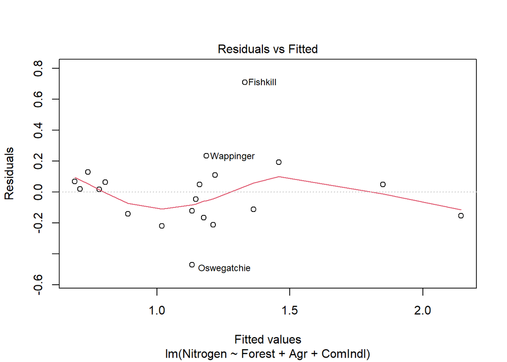

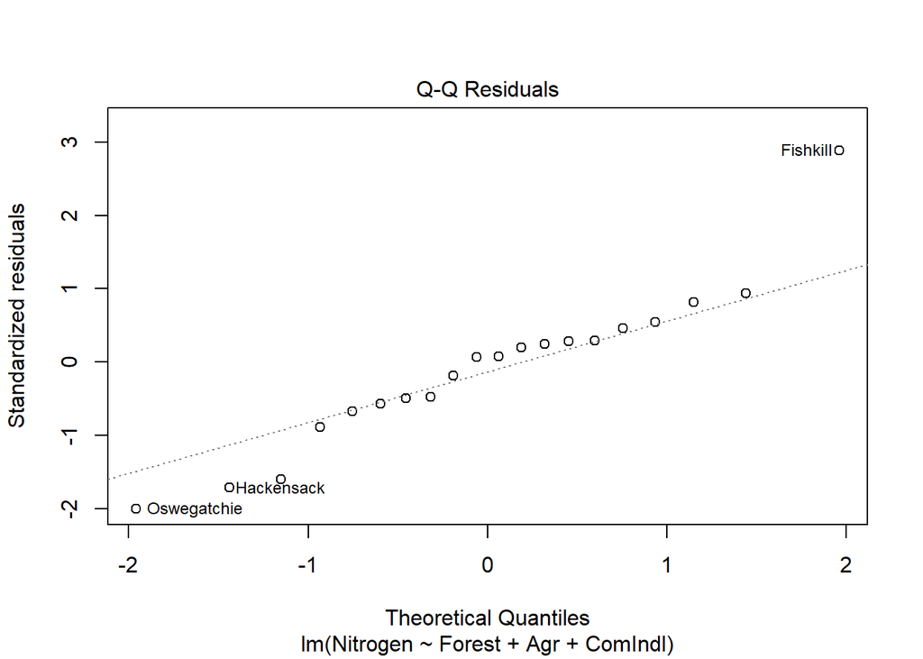

```r
plot(ny_lm, which = c(1,2))
```

###### BCa CI

```r
# BCa CI

library(dplyr)
library(boot)

ny1 <- mutate(ny) |>
  select(Nitrogen, Forest, Agr, ComIndl)
```

###### Resampling Cases

```r
case_resample <- function(df, rows) {
  n <- nrow(df)
  new_data <- df[sample.int(n, n, replace = TRUE), ]
  model <- lm(Nitrogen ~ Forest + ComIndl+Agr, new_data)
  c(coef(model), sigma = sigma(model))
}
```

###### Using boot function

```r
ny_cases_boot <- boot(ny1, case_resample, R = B)
ny_cases_boot
```

```
##
## ORDINARY NONPARAMETRIC BOOTSTRAP
##
##
## Call:
## boot(data = ny1, statistic = case_resample, R = B)
##
##
## Bootstrap Statistics :
##         original        bias    std. error
## t1*  1.638579529 -0.1239882906  1.46309203
## t2* -0.011316488  0.0004596838  0.01637264
## t3*  0.201143326  0.2268621012  0.30806654
## t4*  0.005010659  0.0023845432  0.01708338
## t5*  0.152871411  0.0574476519  0.06657848
```

###### BCa CI for Forest

```r
print(bca_ci_forest <- boot.ci(ny_cases_boot, index = 2, type = 'bca'))
```

```
## BOOTSTRAP CONFIDENCE INTERVAL CALCULATIONS
## Based on 1000 bootstrap replicates
##
## CALL :
## boot.ci(boot.out = ny_cases_boot, type = "bca", index = 2)
##
## Intervals :
## Level       BCa
## 95%   (-0.0487,  0.0225 )
## Calculations and Intervals on Original Scale
```

```r
print(bca_ci_agr <- boot.ci(ny_cases_boot, index = 3, type = 'bca'))
```

```
## BOOTSTRAP CONFIDENCE INTERVAL CALCULATIONS
## Based on 1000 bootstrap replicates
##
## CALL :
## boot.ci(boot.out = ny_cases_boot, type = "bca", index = 3)
##
## Intervals :
## Level       BCa
## 95%   (-0.2665,  0.3941 )
## Calculations and Intervals on Original Scale
## Warning : BCa Intervals used Extreme Quantiles
## Some BCa intervals may be unstable
```

```r
print(bca_ci_comindl <- boot.ci(ny_cases_boot, index = 4, type = 'bca'))
```

```
## BOOTSTRAP CONFIDENCE INTERVAL CALCULATIONS
## Based on 1000 bootstrap replicates
##
## CALL :
## boot.ci(boot.out = ny_cases_boot, type = "bca", index = 4)
##
## Intervals :
## Level       BCa
## 95%   (-0.0417,  0.0327 )
## Calculations and Intervals on Original Scale
## Some BCa intervals may be unstable
```

###### Summary for ny_lm

```r
summary(ny_lm <- lm(Nitrogen ~ Forest + ComIndl, ny1))
```

```
##
## Call:
## lm(formula = Nitrogen ~ Forest + ComIndl, data = ny1)
##
## Residuals:
##      Min       1Q   Median       3Q      Max
## -0.53801 -0.10484 -0.01854  0.07903  0.72398
##
## Coefficients:
##              Estimate Std. Error t value Pr(>|t|)
## (Intercept)  2.096213   0.240457   8.718 1.11e-07 ***
## Forest      -0.016475   0.003455  -4.769 0.000178 ***
## ComIndl      0.187666   0.081607   2.300 0.034413 *
## ---
## Signif. codes:  0 '***' 0.001 '**' 0.01 '*' 0.05 '.' 0.1 ' ' 1
##
## Residual standard error: 0.2555 on 17 degrees of freedom
## Multiple R-squared:  0.6935, Adjusted R-squared:  0.6575
## F-statistic: 19.24 on 2 and 17 DF,  p-value: 4.308e-05
```

### Regression: Resampling Residuals

Use the bootstrap procedure by *resampling residuals* with the model using `Nitrogen` as the response variable and `Forest` and `ComIndl` as two independent variables.

Estimate the bias and standard error of the two partial regression coefficients, and further create percentile and BCa confidence intervals on these two coefficients. Compare the estimated bootstrap standard errors to those produced by the `lm()` function. Further compare your boostrap confidence intervals on the regression coefficients to those produced by the `confint()` function.

###### Modified Residuals

```r
print(e_mod <- rstandard(ny_lm, sd = 1))
```

```
##        Olean    Cassadaga        Oatka    Neversink   Hackensack    Wappinger
## -0.013075445 -0.171136004  0.146552185 -0.111412875 -0.465867344  0.229554126
##     Fishkill     Honeoye   Susquehanna     Chenango  Tioughnioga  West Canada
##  0.756037757  0.234774994 -0.096065840  0.061046413  0.076633218 -0.146468321
##  East Canada      Saranac      Ausable        Black    Schoharie     Raquette
## -0.005166269 -0.028983315  0.070506641  0.102497829 -0.190302540 -0.025370755
##  Oswegatchie     Cohocton
## -0.561147857 -0.067302078
```

```r
mean(e_mod)
```

```
## [1] -0.01023477
```

###### As the mean is not central i.e. (mean =! 0)

```r
e_mod <- e_mod - mean(e_mod)
mean(e_mod)
```

```
## [1] -1.007292e-18
```

###### Error Sampling with replacement

```r
print(e_boot <- sample(e_mod, size = n, replace = TRUE))
```

```
##  East Canada   Hackensack      Saranac     Honeoye   Tioughnioga     Cohocton
##  0.005068505 -0.455632570 -0.018748541  0.245009768  0.086867992 -0.057067304
##      Saranac     Honeoye   Tioughnioga     Cohocton  West Canada  East Canada
## -0.018748541  0.245009768  0.086867992 -0.057067304 -0.136233547  0.005068505
##    Cassadaga  West Canada  Tioughnioga     Honeoye      Fishkill    Neversink
## -0.160901230 -0.136233547  0.086867992  0.245009768  0.766272531 -0.101178101
##     Honeoye         Oatka
##  0.245009768  0.156786959
```

###### Adding random error term

```r
print(y_hat <- fitted.values(ny_lm))
```

```
##        Olean    Cassadaga        Oatka    Neversink   Hackensack    Wappinger
##    1.1127101    1.1740271    1.7767090    1.0838898    2.2350283    1.1963299
##     Fishkill     Honeoye   Susquehanna     Chenango  Tioughnioga  West Canada
##    1.3160211    1.4328272    1.1029119    1.1508752    1.2568171    0.8906133
##  East Canada      Saranac      Ausable        Black    Schoharie     Raquette
##    0.7348315    0.8274197    0.6956195    0.7734115    0.9842484    0.8943666
##  Oswegatchie     Cohocton
##    1.1980087    1.3133339
```

```r
print(y_new <- y_hat + e_boot)
```

```
##        Olean    Cassadaga        Oatka    Neversink   Hackensack    Wappinger
##    1.1177786    0.7183945    1.7579604    1.3288996    2.3218963    1.1392626
##     Fishkill     Honeoye   Susquehanna     Chenango  Tioughnioga  West Canada
##    1.2972726    1.6778370    1.1897799    1.0938079    1.1205835    0.8956818
##  East Canada      Saranac      Ausable        Black    Schoharie     Raquette
##    0.5739303    0.6911861    0.7824875    1.0184213    1.7505209    0.7931885
##  Oswegatchie     Cohocton
##    1.4430185    1.4701208
```

###### Creating temp dataframe to show old and new values

```r
temp_data <- data.frame(y_old = ny$Nitrogen, y_hat = y_hat,
                        error = e_boot, y_new = y_new, Forest = ny$Forest,
                        ComIndl = ny$ComIndl)
print(temp_data)
```

```
##              y_old     y_hat        error     y_new Forest ComIndl
## Olean         1.10 1.1127101  0.005068505 1.1177786     63    0.29
## Cassadaga     1.01 1.1740271 -0.455632570 0.7183945     57    0.09
## Oatka         1.90 1.7767090 -0.018748541 1.7579604     26    0.58
## Neversink     1.00 1.0838898  0.245009768 1.3288996     84    1.98
## Hackensack    1.99 2.2350283  0.086867992 2.3218963     27    3.11
## Wappinger     1.42 1.1963299 -0.057067304 1.1392626     61    0.56
## Fishkill      2.04 1.3160211 -0.018748541 1.2972726     60    1.11
## Honeoye       1.65 1.4328272  0.245009768 1.6778370     43    0.24
## Susquehanna   1.01 1.1029119  0.086867992 1.1897799     62    0.15
## Chenango      1.21 1.1508752 -0.057067304 1.0938079     60    0.23
## Tioughnioga   1.33 1.2568171 -0.136233547 1.1205835     53    0.18
## West Canada   0.75 0.8906133  0.005068505 0.8956818     75    0.16
## East Canada   0.73 0.7348315 -0.160901230 0.5739303     84    0.12
## Saranac       0.80 0.8274197 -0.136233547 0.6911861     81    0.35
## Ausable       0.76 0.6956195  0.086867992 0.7824875     89    0.35
## Black         0.87 0.7734115  0.245009768 1.0184213     82    0.15
## Schoharie     0.80 0.9842484  0.766272531 1.7505209     70    0.22
## Raquette      0.87 0.8943666 -0.101178101 0.7931885     75    0.18
##  Oswegatchie  0.66 1.1980087  0.245009768 1.4430185     56    0.13
## Cohocton      1.25 1.3133339  0.156786959 1.4701208     49    0.13
```

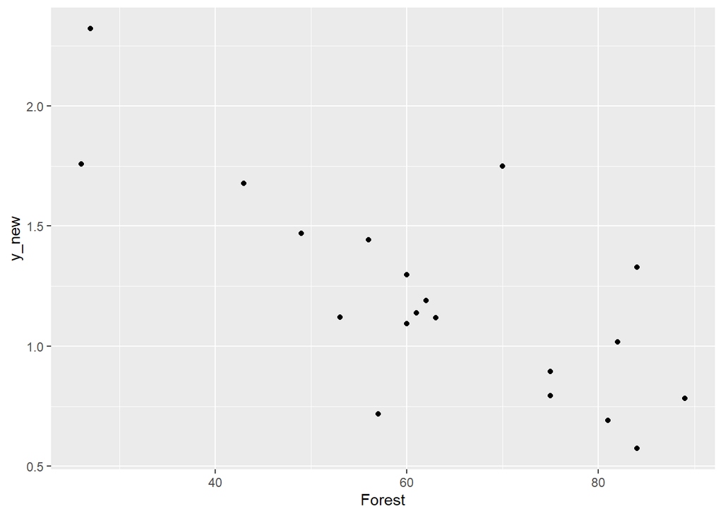

```r
ggplot(temp_data, aes(x = Forest, y = y_new)) +
  geom_point()
```

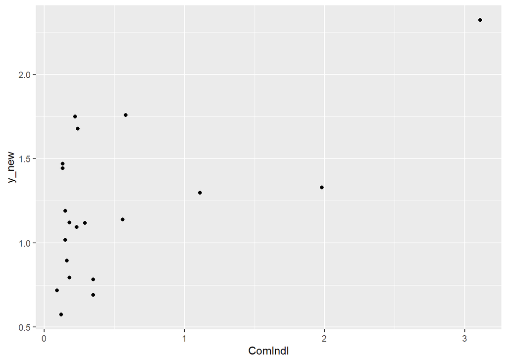

```r
ggplot(temp_data, aes(x = ComIndl, y = y_new)) +
  geom_point()
```

```r
summary(lm(y_new ~ (Forest + ComIndl), temp_data))
```

```
##
## Call:
## lm(formula = y_new ~ (Forest + ComIndl), data = temp_data)
##
## Residuals:
##      Min       1Q   Median       3Q      Max
## -0.48286 -0.11951 -0.03412  0.11554  0.71867
##
## Coefficients:
##              Estimate Std. Error t value Pr(>|t|)
## (Intercept)  2.053978   0.238291   8.620  1.3e-07 ***
## Forest      -0.015322   0.003424  -4.475 0.000333 ***
## ComIndl      0.229091   0.080872   2.833 0.011485 *
## ---
## Signif. codes:  0 '***' 0.001 '**' 0.01 '*' 0.05 '.' 0.1 ' ' 1
##
## Residual standard error: 0.2532 on 17 degrees of freedom
## Multiple R-squared:    0.7,  Adjusted R-squared:  0.6647
## F-statistic: 19.83 on 2 and 17 DF,  p-value: 3.595e-05
```

###### Sampling from Modified Residuals

```r
cal_err_boot <- replicate(B,
                           expr = { e_new <- sample(e_mod, n, replace = TRUE);
                           y_new <- fitted(ny_lm) + e_new;
                           new_lm <- lm(y_new ~ (Forest + ComIndl), data = ny);
                           c(coef(new_lm), sigma(new_lm)) })
cal_err_boot <- t(cal_err_boot)

case_resample <- function(df, rows) {
  n <- nrow(df)
  new_data <- df[sample.int(n, n, replace = TRUE), ]
  model <- lm(Nitrogen ~ Forest + ComIndl, new_data)
  c(coef(model), sigma = sigma(model))
}
```

```r
print(ny_lm <- lm(Nitrogen ~ Forest + ComIndl, ny))
```

```
##
## Call:
## lm(formula = Nitrogen ~ Forest + ComIndl, data = ny)
##
## Coefficients:
## (Intercept)       Forest      ComIndl
##     2.09621     -0.01648      0.18767
```

```r
print(theta_hat <- c(coef(ny_lm), sigma = sigma(ny_lm)))
```

```
## (Intercept)      Forest     ComIndl       sigma
##  2.09621335 -0.01647502  0.18766577  0.25554930
```

###### Bootstrap Bias

```r
#Bias
print(bias <- (colMeans(cal_err_boot)) - theta_hat)
```

```
##   (Intercept)        Forest       ComIndl
##  3.725996e-04 -3.899454e-05  4.948109e-03 -4.205476e-03
```

###### Bootstrap Standard Error Comparison

```r
# SE
apply(cal_err_boot, 2, sd)
```

```
## (Intercept)      Forest     ComIndl
## 0.258169642 0.003687584 0.086186773 0.064084878
```

```r
summary(ny_lm)$coef[, "Std. Error"]
```

```
## (Intercept)      Forest     ComIndl
## 0.240457363 0.003454675 0.081607178
```

###### Confidence Interval Comparison

```r
# Percentile CI

apply(cal_err_boot, 2, function(x) quantile(x, c(0.025, 0.975)))
```

```
##       (Intercept)      Forest    ComIndl
## 2.5%     1.571475 -0.02351623 0.03055972 0.1327691
## 97.5%    2.610678 -0.00897528 0.39075712 0.3804907
```

```r
confint(ny_lm)
```

```
##                   2.5 %       97.5 %
## (Intercept)  1.58889266  2.603534045
## Forest      -0.02376375 -0.009186293
## ComIndl      0.01548968  0.359841866
```

###### BCa Interval Calculation using boot package

```r
ny_residual <- function(df, rows) {
  err <- e_mod[rows]
  y_new <- y_hat + err
  model <- lm(y_new ~ Forest + ComIndl, ny)
  c(coef(model))
}


ny_error_boot <- boot(e_mod, ny_residual, R = 1000)

ny_error_boot
```

```
##
## ORDINARY NONPARAMETRIC BOOTSTRAP
##
##
## Call:
## boot(data = e_mod, statistic = ny_residual, R = 1000)
##
##
## Bootstrap Statistics :
##        original        bias    std. error
## t1*  2.09831942 -0.0177709830 0.233633155
## t2* -0.01609048 -0.0001986662 0.003305176
## t3*  0.13669741  0.0473087677 0.076879186
```

###### BCa CI for Forest

```r
boot.ci(ny_error_boot, index = 2, type = 'bca')
```

```
## BOOTSTRAP CONFIDENCE INTERVAL CALCULATIONS
## Based on 1000 bootstrap replicates
##
## CALL :
## boot.ci(boot.out = ny_error_boot, type = "bca", index = 2)
##
## Intervals :
## Level       BCa
## 95%   (-0.0231, -0.0101 )
## Calculations and Intervals on Original Scale
```

###### BCa CI for ComIndl

```r
boot.ci(ny_error_boot, index = 3, type = 'bca')
```

```
## BOOTSTRAP CONFIDENCE INTERVAL CALCULATIONS
## Based on 1000 bootstrap replicates
##
## CALL :
## boot.ci(boot.out = ny_error_boot, type = "bca", index = 3)
##
## Intervals :
## Level       BCa
## 95%   (-0.0753,  0.2226 )
## Calculations and Intervals on Original Scale
## Warning : BCa Intervals used Extreme Quantiles
## Some BCa intervals may be unstable
```